# tidyexposomics: integrated exposure-omics analysis powered by the tidyverse

Jason Laird

Compiled: March 01, 2025

[figure not shown]

# 1 Introduction

Exposure to environmental factors is a major determinant of health and disease. The exposome is a term that represents the totality of environmental exposures that drive disease and overall health [(Wild et al. 2005)](https://pubmed.ncbi.nlm.nih.gov/16103423/). To tackle the daunting task of characterizing the relationship between a multiplicity of exposures and disease outcomes, epidemiological studies have moved towards exposure wide association studies (ExWAS) where sets of exposures are associated with an outcome [(Chung et al. 2024)](https://academic.oup.com/exposome/article/4/1/osae001/7574628). The advent of high-throughput technologies has enabled profiling of several layers of biological information. These layers too can be integrated to better understand the relationship between exposures and disease outcomes.

The `tidyexposomics` package is designed to facilitate the integration of exposure and omics data to identify exposure-omics associations. We structure our commands to fit into the `tidyverse` framework, where commands are designed to be simplified and intuitive. Here we provide functionality to perform quality control, sample and exposure association analysis, differential abundance analysis, multi-omics integration, and functional enrichment analysis.

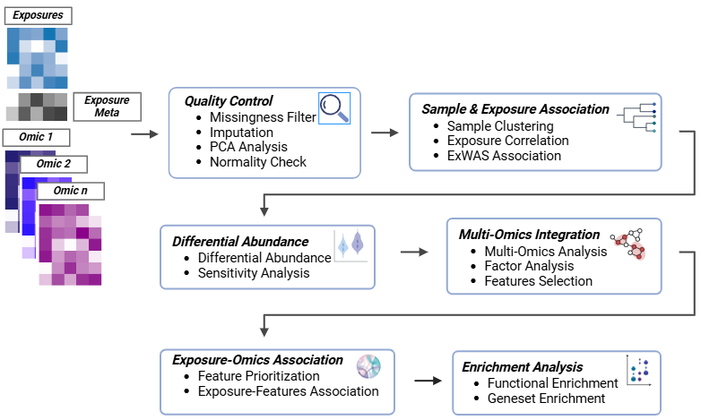

Figure 1: tidyexposomics pipeline overview  
Exposure and omics data are stored in a MultiAssayExperiment. Data then undergo quality cotnrol, sample and exposure associations, differential abundance analysis, multi-omics integration, and functional enrichment analysis. The pipeline is designed to be flexible and modular, allowing users to customize their analysis.

# 2 Installation

```r
# install the current development version
devtools::install_github("BioNomad/tidyexposomics")
```

# 3 Loading Data

To get started we need to load the data. The `expOmicSet` function is used to create a MultiAssayExperiment object that contains the exposure and omics data. As a quick introduction, a MultiAssayExperiment object is a container for storing multiple assays (e.g., omics data) and their associated metadata:

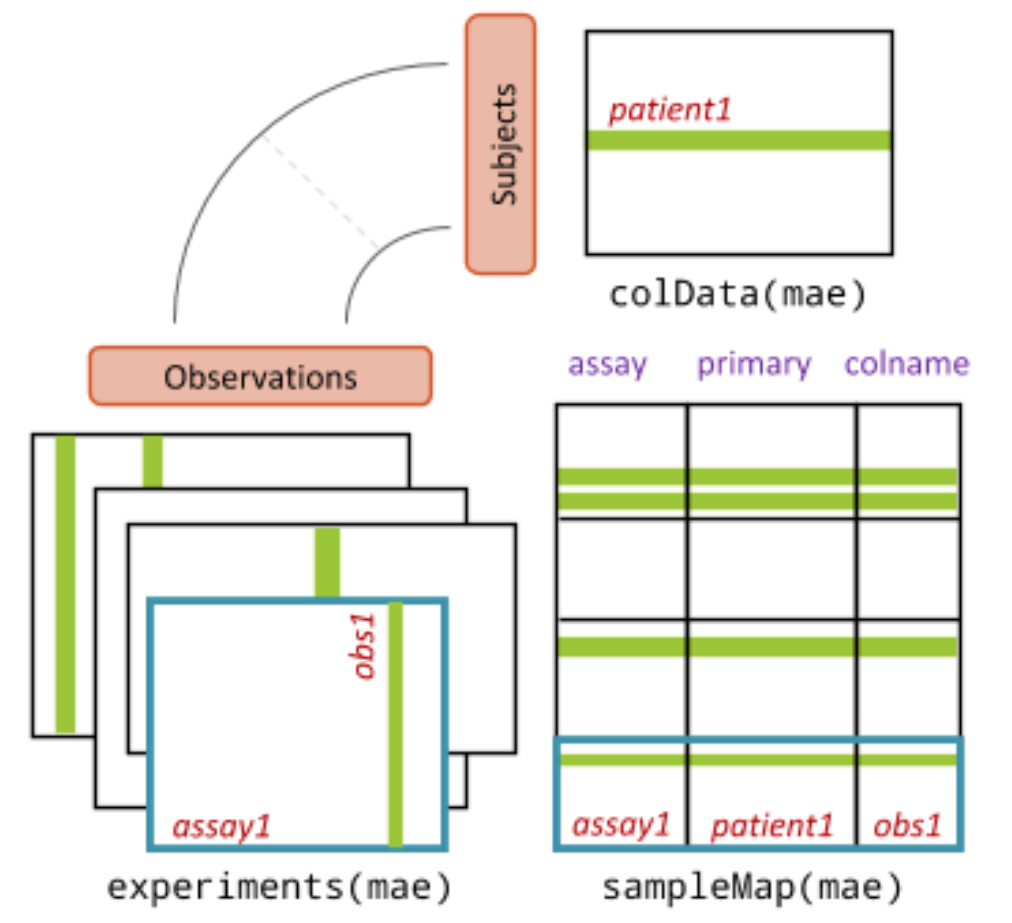

Figure 2: Overview of the MultiAssayExperiment Object Structure  
Subject level data is captured within the `colData` of the MultiAssayExperiment. Observations are stored within `experiments` slots in the MultiAssayExperiment and `sampleMap` is used to link the data ( [MultiAssay Special Interest Group 2024](https://www.bioconductor.org/packages/release/bioc/vignettes/MultiAssayExperiment/inst/doc/MultiAssayExperiment.html) ).

We use the MultiAssayExperiment object to store the exposure and omics data. The `expOmicSet` function takes several arguments:

- The `var_info` argument is a data frame that contains information about the variables in the exposure meta data.
- The `exposure` argument is a data frame that contains the exposure data,
- The `omics` argument is a list of data frames that contain the omics data.
- The `row_data` argument is a list of data frames that contain information about the rows of each omics data frame.

```r
# Create list of omics data frames
omics_list <- list(
  "CD16+ Monocyte RNA" = cd16_rna,
  "CD4+ T-cell RNA" = cd4_rna,
  "CD4+ T-cell miRNA"= cd4_mirna,
  "CD16+ Monocyte miRNA" = cd16_mirna,
  "Serum Proteomics" = prot_abd_unnorm,
  "Serum Adductomics" = adduct
)

# Create list of omics row data data frames
fdata <- list(
  "CD16+ Monocyte RNA" = cd16_rna_fdata,
  "CD4+ T-cell RNA" = cd4_rna_fdata,
  "CD4+ T-cell miRNA"= cd4_mirna_fdata,
  "CD16+ Monocyte miRNA" = cd16_mirna_fdata,
  "Serum Proteomics" = prot_fdata,
  "Serum Adductomics" = adduct_fdata
)

# Create the expOmicSet object
expom <- expOmicSet(
  var_info = des,
  exposure = aw_dataset_cv2_filt,
  omics = omics_list,
  row_data = fdata)
```

# 4 Quality Control

## 4.1 Missingness

Oftentimes when collecting data, there are missing values. The `filter_missing` function is used to filter out variables with too many missing values. The `na_thresh` argument is used to set the threshold for missing values. For example, if `na_thresh = 20`, then any variable with more than 20% missing values will be removed.

```r
expom_qc <- expom |>
  # Filter out variables with too many missing values
  filter_missing(na_thresh = 20)
```

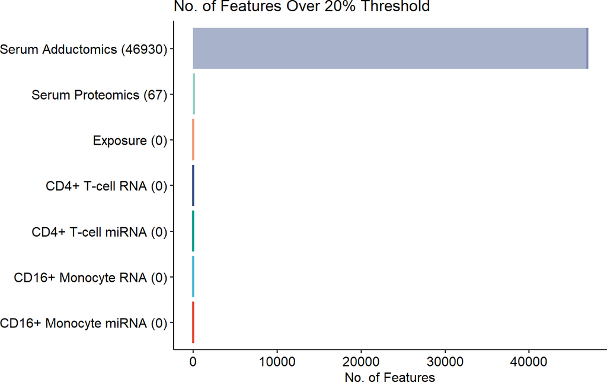

```r
# Check the number of missing values
expom_qc |>
  plot_missing_summary(threshold = 20)
```

## 4.2 Imputation

Now that we have filtered out the variables with too many missing values, we can impute the missing values. The `impute_missing` function is used to impute missing values.

```r
# Impute missing values
expom_qc <- expom_qc |>
  impute_missing(
    exposure_impute_method = "median",
    omics_impute_method = "median")
```

## 4.3 PCA Analysis

To identify the spread of the data, we can perform a principal component analysis (PCA). The `pca_analysis` function is used to perform PCA on samples with observations in each omics data frame. The `plot_pca` function is used to plot the PCA results. We automatically identify sample outliers based on the Mahalanobis distance, a measure of the distance between a point and a distribution.

```r
# Perform PCA analysis
expom_qc <- expom_qc |>

  # Principal component analysis
  pca_analysis()
```

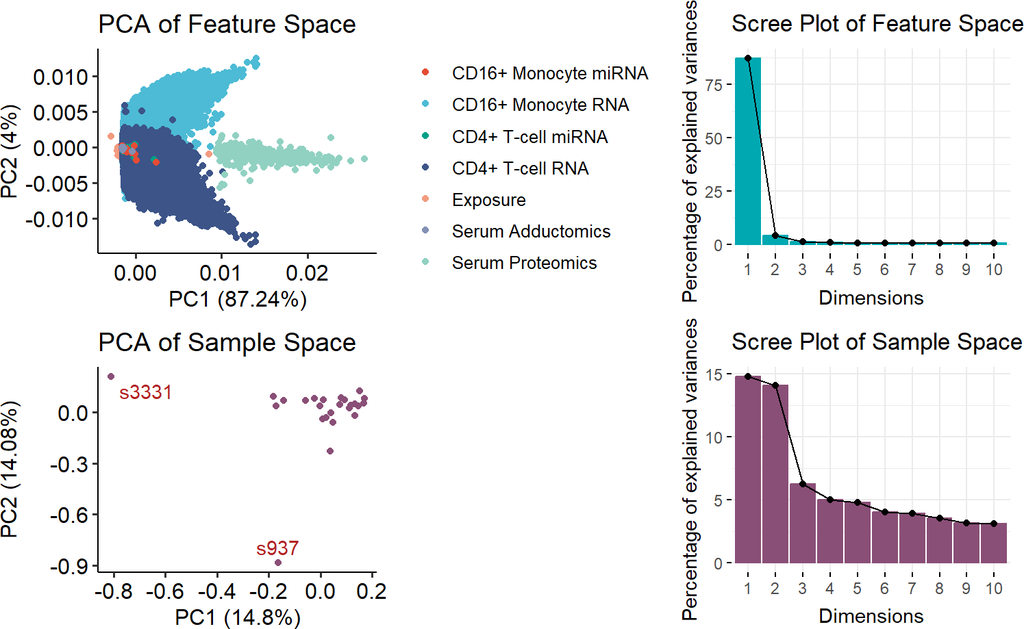

```r
# Plot PCA analysis
expom_qc |>
  plot_pca()
```

## 4.4 Normality Check

When determining variable associations it is important to check the normality of the data. The `check_normality` function is used to check the normality of the data. The `transform_exposure` function is used to transform the data to make it more normal. Here the `transform_method` is set to `best` as it will compare the normality of the data before and after transformation and select the best method. The `transform_method` can be set to `log2`, `sqrt`, or `x_1_3`.

```r
# Check Variable Normality
expom_qc <- expom_qc |>
  # Check Variable Normality
  check_normality() |>

  # Transform Variables
  transform_exposure(transform_method = "best")
```

```r
# expom_qc |>
#   plot_normality_sum()
```

# 5 Sample-Exposure Association

## 5.1 Sample Clustering

The `cluster_samples` function is used to cluster samples based on the exposure data. The `clustering_approach` argument is used to set the clustering approach. The `clustering_approach` can be set to `diana`, `gap`, or `elbow`.

```r
# Sample Clustering
expom_sample_exp <- expom_qc |>
  cluster_samples(exposure_cols = exp_vars,
                  clustering_approach = "diana")
```

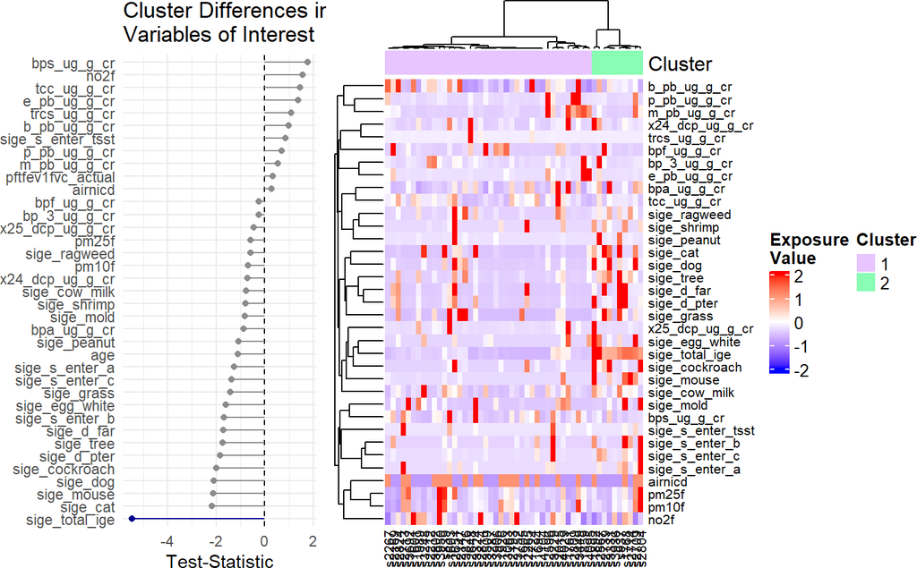

```r
# Plot Sample Clusters
expom_sample_exp |>
  plot_sample_clusters(
    cols_of_interest = c(exp_vars,"age","pftfev1fvc_actual"))
```

Here we see two clusters, largely driven by levels of Immunoglobulin E.

## 5.3 ExWAS Association

The `perform_exwas` function is used to perform ExWAS analysis. The `outcome` argument is used to set the outcome variable. The `exposures` argument is used to set the exposures of interest. The `covariates` argument is used to set the covariates to adjust for.

```r
# Perform ExWAS Analysis
expom_sample_exp <- expom_sample_exp |>
  perform_exwas(
    outcome = "pftfev1fvc_actual",
    exposures = all_vars[
      !all_vars %in% c("pftfev1fvc_actual",
                       "age",
                       "sex",
                       "race")],
    covariates = c("age","sex","race"))
```

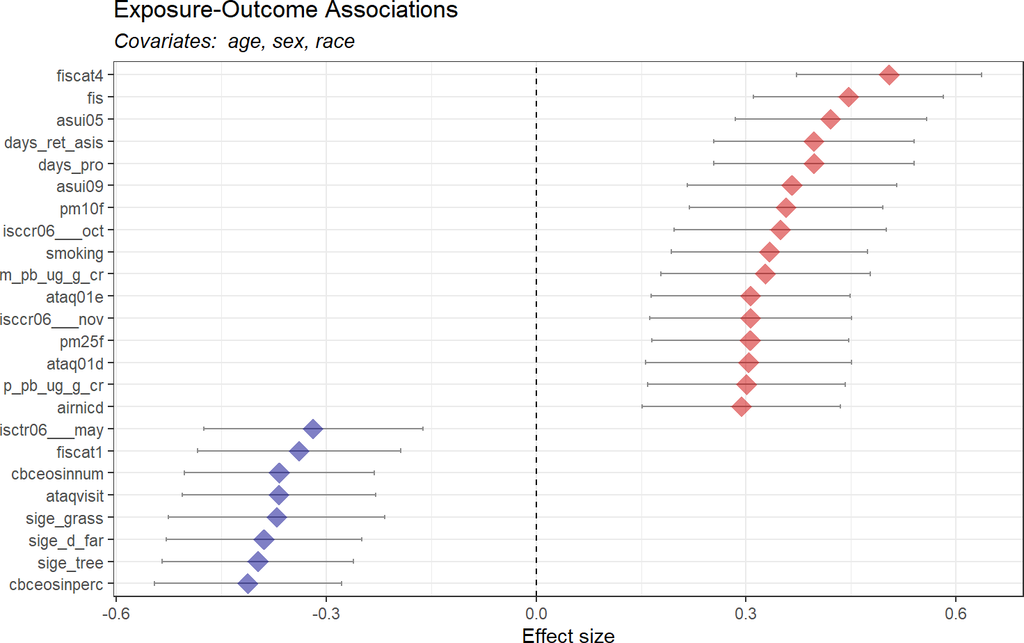

```r
expom_sample_exp |>
  plot_exp_outcome_association()
```

Here we see that PM10/PM2.5 exposure, and eosinophil levels are associated with FEV1/FVC after adjusting for age, sex, and race.